# Coreid_antennae_evolution

## ADULTS - GENUS LEVEL

```r
# Now, we will use the adults data colapsed at genus level

adults_data2 = gen_adults %>%
  filter(Antennae != 0,
         !Species_Name %in% c("Jadera_haematoloma", "Harmostes_serratus",
                              "Oedancala_sp.", "Oncopeltus_fasciatus",
                              "Largus_sp.", "Dysdercus_mimus",
                              "Dysdercus_suturellus", "Halyomorpha_halys")) %>%
  mutate(Species_Name = case_when(
    Species_Name == "Holhymenia_tibialis" ~ "Holhymenia_tibialis / clavigera",
    TRUE ~ Species_Name
  ))

# We need to make sure that only species present in nymphal data are present
# in the adults data, so we can compare them equally

adults_data2 = gen_adults %>%
  mutate(Species_Name = case_when(
    Species_Name == "Holhymenia_tibialis" ~ "Holhymenia_tibialis / clavigera",
    TRUE ~ Species_Name
  )) %>%
  filter(Antennae != 0,
         !Species_Name %in% c("Jadera_haematoloma", "Harmostes_serratus",
                              "Oedancala_sp.", "Oncopeltus_fasciatus",
                              "Largus_sp.", "Dysdercus_mimus",
                              "Dysdercus_suturellus", "Halyomorpha_halys"),
         Species_Name %in% nymph_data$Species_Name)
```

```r
# Now we prune the tree to the data we have on Coreidae adults genera

t_adults_gen = keep.tip(t1, adults_data2$Species_Name)

# adults matrix

adults.gen.sim = setNames(as.factor(adults_data2$Sum), adults_data2$Species_Name)
adults.gen.sim
```

```
##         Acanthocephala_femorata           Acanthocoris_sordidus
##                               3                               3
##            Physomerus_grossipes              Petascelis_remipes
##                               3                               3
##                Sephina_subulata              Spartocera_batatas
##                               3                               3
##               Alydus_calcaratus          Neomegalotomus_rufipes
##                               3                               3
##            Apidaurus_conspersus             Camptopus_lateralis
##                               3                               3
##             Hamedius_incarnatus             Riptortus_pedestris
##                               3                               3
##              Heegeria_tangirica                    Nariscus_sp.
##                               3                               3
##               Melanacanthus_sp.                    Tenosius_sp.
##                               3                               3
##          Hyalymenus_longispinus              Arenocoris_waltlii
##                               3                               3
##              Bathysolen_nubilus         Coriomeris_denticulatus
##                               3                               3
##       Strobilotoma_typhaecornis        Ceraleptus_gracilicornis
##                               3                               3
##                 Clavigralla_sp.               Leptocorisa_acuta
##                               3                               3
##           Stenocoris_tipuloides             Mutusca_brevicornis
##                               3                               3
##             Madura_fuscoclavata               Nematopus_lepidus
##                               3                               3
##       Mozena_lineolata (lunata)          Piezogaster_calcarator
##                               3                               3
##             Ouranion_serrulatus            Melucha_quadrivittis
##                               3                               3
##        Pachylis_neocalifornicus          Agriopocoris_froggatti
##                               4                               3
##                       Hygia_sp.              Amorbus_alternatus
##                               3                               3
##              Mirabilamorbus_sp.              Gelonus_tasmanicus
##                               3                               3
##           Anoplocnemis_phasiana                  Elasmopoda_sp.
##                               3                               3
```

[output cut: 34 more lines]

```
##            Leptoscelis_tricolor             Paryphes_pulchellus
##                               3                               3
##                Anasa_varicornis                Anasa_scorbutica
##                               3                               3
##              Anisoscelis_alipes           Anisoscelis_gradadius
##                               3                               3
##          Chondrocera_laticornis Holhymenia_tibialis / clavigera
##                               5                               5
##             Chelinidea_tabulata             Chelinidea_vittiger
##                               6                               6
##             Plaxiscelis_limbata          Stenoeurilla_aenescens
##                               3                               3
##             Laminiceps_vergarae
##                               3
## Levels: 3 4 5 6
```

```r
# Mk model
#fit.ER.equal.ag = fitMk(ladderize(t_adults_gen), adults.gen.sim, model = "ER",
#           pi = 'equal')


#fit.ER.fitz.ag = fitMk(ladderize(t_adults_gen), adults.gen.sim , model = "ER",
#                 pi = 'fitzjohn')

#save(fit.ER.equal.ag, file = '~/Library/CloudStorage/OneDrive-Personal/Orientados/IC - Mariana/antennae-evol/coreidae_antennae/evo.models/er-equal-adults-genus.RData')
#save(fit.ER.fitz.ag, file = '~/Library/CloudStorage/OneDrive-Personal/Orientados/IC - Mariana/antennae-evol/coreidae_antennae/evo.models/er-fitz-adults-genus.RData')

load( file = '~/Library/CloudStorage/OneDrive-Personal/Orientados/IC - Mariana/antennae-evol/coreidae_antennae/evo.models/er-equal-adults-genus.RData')
load( file = '~/Library/CloudStorage/OneDrive-Personal/Orientados/IC - Mariana/antennae-evol/coreidae_antennae/evo.models/er-fitz-adults-genus.RData')

#fit.ARD.equal.ag = fitMk(ladderize(t_adults_gen), adults.gen.sim, model = "ARD",
#                        pi = 'equal')

#fit.ARD.fitz.ag = fitMk(ladderize(t_adults_gen), adults.gen.sim, model = "ARD",
#                       pi = 'fitzjohn')

#save(fit.ARD.equal.ag, file = '~/Library/CloudStorage/OneDrive-Personal/Orientados/IC - Mariana/antennae-evol/coreidae_antennae/evo.models/ARD-equal-adults-genus.RData')
#save(fit.ARD.fitz.ag, file = '~/Library/CloudStorage/OneDrive-Personal/Orientados/IC - Mariana/antennae-evol/coreidae_antennae/evo.models/ARD-fitz-adults-genus.RData')

load( file = '~/Library/CloudStorage/OneDrive-Personal/Orientados/IC - Mariana/antennae-evol/coreidae_antennae/evo.models/ARD-equal-adults-genus.RData')
load( file = '~/Library/CloudStorage/OneDrive-Personal/Orientados/IC - Mariana/antennae-evol/coreidae_antennae/evo.models/ARD-fitz-adults-genus.RData')

# Hidden rates model, HRM

#fitHRM.er.equal.ag = fitHRM(ladderize(t_adults_gen), adults.gen.sim, model = "ER",
#                           pi = 'equal')

#fitHRM.er.fitz.ag = fitHRM(ladderize(t_adults_gen), adults.gen.sim, model = "ER",
#                          pi = 'fitzjohn')

#save(fitHRM.er.equal.ag, file = '~/Library/CloudStorage/OneDrive-Personal/Orientados/IC - Mariana/antennae-evol/coreidae_antennae/evo.models/hrm-er-equal-adults-genus.RData')
#save(fitHRM.er.fitz.ag, file = '~/Library/CloudStorage/OneDrive-Personal/Orientados/IC - Mariana/antennae-evol/coreidae_antennae/evo.models/hrm-er-fitz-adults-genus.RData')

load(file = '~/Library/CloudStorage/OneDrive-Personal/Orientados/IC - Mariana/antennae-evol/coreidae_antennae/evo.models/hrm-er-equal-adults-genus.RData')
load(file = '~/Library/CloudStorage/OneDrive-Personal/Orientados/IC - Mariana/antennae-evol/coreidae_antennae/evo.models/hrm-er-fitz-adults-genus.RData')

#fitHRM.ard.equal.ag = fitHRM(ladderize(t_adults_gen), adults.gen.sim, model = "ARD",
#                            pi = 'equal')


#fitHRM.ard.fitz.ag = fitHRM(ladderize(t_adults_gen), adults.gen.sim, model = "ARD",
#                           pi = 'fitzjohn')

#save(fitHRM.ard.equal.ag, file = '~/Library/CloudStorage/OneDrive-Personal/Orientados/IC - Mariana/antennae-evol/coreidae_antennae/evo.models/hrm-equal-adults-genus.RData')
#save(fitHRM.ard.fitz.ag, file = '~/Library/CloudStorage/OneDrive-Personal/Orientados/IC - Mariana/antennae-evol/coreidae_antennae/evo.models/hrm-fitz-adults-genus.RData')


load(file = '~/Library/CloudStorage/OneDrive-Personal/Orientados/IC - Mariana/antennae-evol/coreidae_antennae/evo.models/hrm-equal-adults-genus.RData')
load(file = '~/Library/CloudStorage/OneDrive-Personal/Orientados/IC - Mariana/antennae-evol/coreidae_antennae/evo.models/hrm-fitz-adults-genus.RData')


# Comparing models
fit_models_ag = anova(fit.ER.equal.ag, fit.ARD.equal.ag,
                      fitHRM.er.equal.ag, fitHRM.ard.equal.ag,
                      fit.ER.fitz.ag, fit.ARD.fitz.ag,
                      fitHRM.er.fitz.ag, fitHRM.ard.fitz.ag)
```

```
##                        log(L) d.f.       AIC       weight
## fit.ER.equal.ag     -36.36419    1  74.72838 1.534744e-01
## fit.ARD.equal.ag    -29.35045   12  82.70089 2.849882e-03
## fitHRM.er.equal.ag  -35.73121    3  77.46242 3.911526e-02
## fitHRM.ard.equal.ag -28.70868   32 121.41736 1.115970e-11
## fit.ER.fitz.ag      -34.97866    1  71.95732 6.134273e-01
## fit.ARD.fitz.ag     -28.98499   12  81.96998 4.107161e-03
## fitHRM.er.fitz.ag   -34.16648    3  74.33295 1.870260e-01
## fitHRM.ard.fitz.ag  -28.60010   32 121.20020 1.243967e-11
```

```r
# It was chosen the ER fitz model once it had the lowest AIC value and
# 1 degree of freedom

fit.ER.fitz.ag
```

```
## Object of class "fitMk".
##
## Fitted (or set) value of Q:
##           3         4         5         6
## 3 -1.300506  0.433502  0.433502  0.433502
## 4  0.433502 -1.300506  0.433502  0.433502
## 5  0.433502  0.433502 -1.300506  0.433502
## 6  0.433502  0.433502  0.433502 -1.300506
##
## Fitted (or set) value of pi:
##        3        4        5        6
## 0.999617 0.000128 0.000128 0.000128
## due to treating the root prior as (a) nuisance.
##
## Log-likelihood: -34.978662
##
## Optimization method used was "nlminb"
##
## R thinks it has found the ML solution.
```

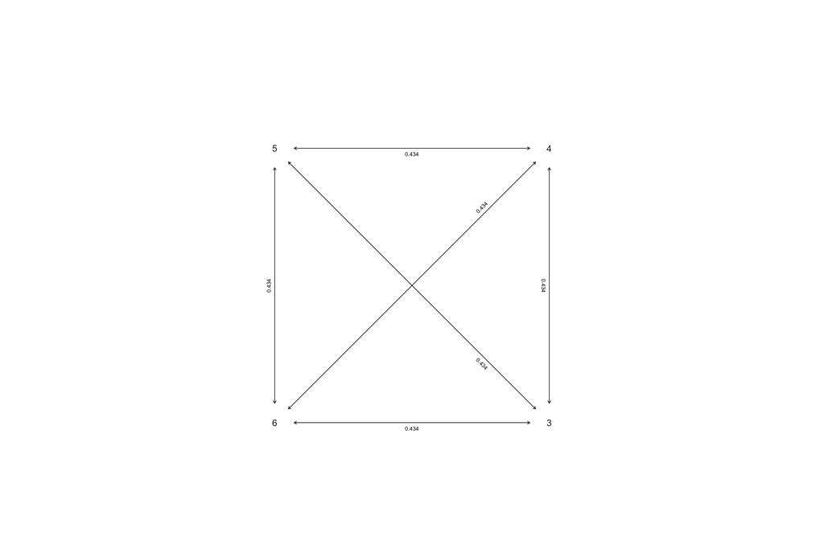

```r
plot(fit.ER.fitz.ag)
```

## PLOTTING NYMPHS AND ADULTS GENERA TREE TOGETHER

```r
#Nymph
anc.nymph = ancr(fitHRM.er.fitz.nymph, hide.hidden = F)

#Adults
anc.ag = ancr(fit.ER.fitz.ag)

tree_plot = fit.ER.fitz.ag$tree

anc.nymph$tree = tree_plot
anc.ag$tree = tree_plot

states = colnames(anc.nymph$ace)
cols = setNames(
  c("#0E3768","blue", "#94129F", "#ea22fb",
    "#DE627A", "pink", "#ce4326", "#ff8b5f"),
  states
)

states2 = colnames(anc.ag$ace)
cols2 = setNames(
  c("#0E3768", "#94129F",
    "#DE627A",  "#ce4326"),
  states2
)
cols2
```

```
##         3         4         5         6
## "#0E3768" "#94129F" "#DE627A" "#ce4326"
```

```r
tip_state = as.character(nymphs.gen.sim[anc.nymph$tree$tip.label])
states2
```

```
## [1] "3" "4" "5" "6"
```

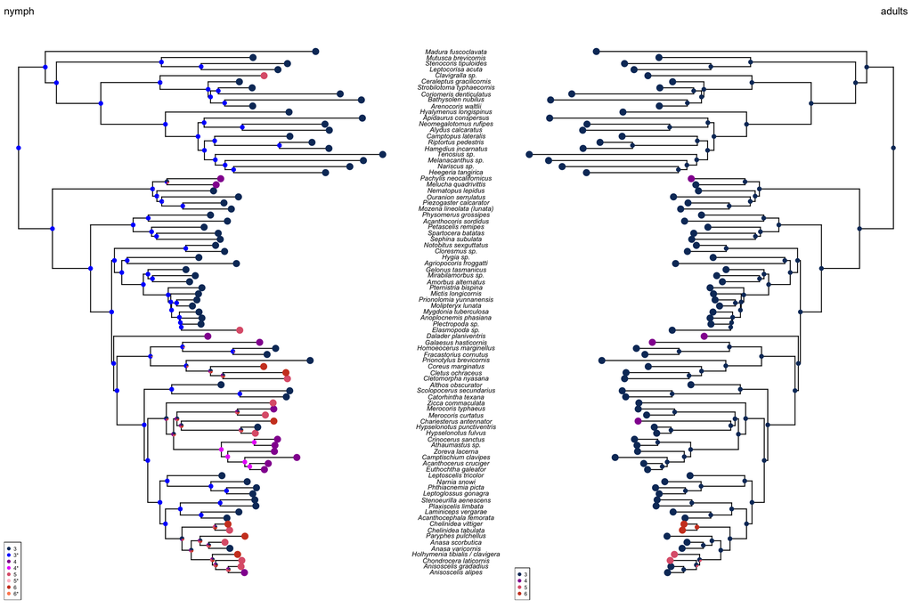

```r
tip.pies = sapply(
  states2,
  function(z) as.numeric(tip_state == z)
)

tip.pies = as.matrix(tip.pies)
rownames(tip.pies) = anc.nymph$tree$tip.label
colnames(tip.pies) = states2

#png(file = './figures/ancestral-facing.png', height = 400, width = 350,
#    units = "mm", res = 300)
#pdf(file = './figures/antennnomere_facing.pdf',
#    h = 12, w = 12)

layout(matrix(1:3, nrow = 1), widths = c(0.44, 0.12, 0.44))

plot(
  anc.nymph,
  args.plotTree = list(
    ftype = "off",
    lwd = 1.5,
    ylim = c(0, Ntip(tree_plot) + 1),
    mar = c(1, 0.5, 3, 0.5)
  ),
  args.nodelabels = list(
    piecol = cols,
    cex = 0.3
  )
)
par(fg = 'transparent')
tiplabels(
  pie = tip.pies,
  piecol = cols2,
  cex = 0.45,
  border = "transparent"
)
par(fg = 'black')
mtext("nymph", side = 3, line = 1, adj = 0)

## Middle: taxon labels, plotted once
pp <- get("last_plot.phylo", envir = .PlotPhyloEnv)

## Tips are nodes 1:Ntip(tree); arrange bottom to top
tip_order <- order(pp$yy[seq_len(Ntip(tree_plot))])

tip_labels <- tree_plot$tip.label[tip_order]
tip_y      <- pp$yy[tip_order]
y_lim      <- pp$y.lim

## Middle panel: use the plotted y coordinates, NOT 1:Ntip()
plot.new()
plot.window(xlim = c(-1, 1), ylim = y_lim)

text(
  x = 0,
  y = tip_y,
  labels = gsub("_", " ", tip_labels),
  cex = 1,
  font = 3
)


plot(
  anc.ag,
  args.plotTree = list(
    ftype = "off",
    direction = "leftwards",
    lwd = 1.5,
    ylim = c(0, Ntip(tree_plot) + 1),
    mar = c(1, 0.5, 3, 0.5)
  ),
  args.nodelabels = list(
    piecol = cols2,
    cex = 0.3
  ),
  args.tiplabels = list(
    cex = 0.45
  )
)
mtext("adults", side = 3, line = 1, adj = 1)
```

## SESSION INFO

```r
sessionInfo() %>% pander
```

**R version 4.6.0 (2026-04-24)**

**Platform:** aarch64-apple-darwin23

**locale:** en_US.UTF-8||en_US.UTF-8||en_US.UTF-8||C||en_US.UTF-8||en_US.UTF-8

**attached base packages:** *stats*, *graphics*, *grDevices*, *utils*, *datasets*, *methods* and *base*

**other attached packages:** *pander(v.0.6.6)*, *lubridate(v.1.9.5)*, *forcats(v.1.0.1)*, *stringr(v.1.6.0)*, *dplyr(v.1.2.1)*, *purrr(v.1.2.2)*, *readr(v.2.2.0)*, *tidyr(v.1.3.2)*, *tibble(v.3.3.1)*, *ggplot2(v.4.0.3)*, *tidyverse(v.2.0.0)*, *diversitree(v.0.10-1)*, *geiger(v.2.0.11)*, *phytools(v.2.5-2)*, *maps(v.3.4.3)* and *ape(v.5.8-1)*

**loaded via a namespace (and not attached):** *fastmatch(v.1.1-8)*, *gtable(v.0.3.6)*, *xfun(v.0.57)*, *bslib(v.0.11.0)*, *lattice(v.0.22-9)*, *tzdb(v.0.5.0)*, *numDeriv(v.2016.8-1.1)*, *quadprog(v.1.5-8)*, *vctrs(v.0.7.3)*, *tools(v.4.6.0)*, *generics(v.0.1.4)*, *stats4(v.4.6.0)*, *parallel(v.4.6.0)*, *pkgconfig(v.2.0.3)*, *Matrix(v.1.7-5)*, *RColorBrewer(v.1.1-3)*, *S7(v.0.2.2)*, *scatterplot3d(v.0.3-45)*, *lifecycle(v.1.0.5)*, *compiler(v.4.6.0)*, *farver(v.2.1.2)*, *mnormt(v.2.1.2)*, *subplex(v.1.9)*, *combinat(v.0.0-8)*, *codetools(v.0.2-20)*, *htmltools(v.0.5.9)*, *sass(v.0.4.10)*, *yaml(v.2.3.12)*, *pillar(v.1.11.1)*, *jquerylib(v.0.1.4)*, *MASS(v.7.3-65)*, *cachem(v.1.1.0)*, *clusterGeneration(v.1.3.8)*, *iterators(v.1.0.14)*, *foreach(v.1.5.2)*, *nlme(v.3.1-169)*, *phangorn(v.2.12.1)*, *tidyselect(v.1.2.1)*, *digest(v.0.6.39)*, *stringi(v.1.8.7)*, *mvtnorm(v.1.3-7)*, *fastmap(v.1.2.0)*, *grid(v.4.6.0)*, *expm(v.1.0-0)*, *cli(v.3.6.6)*, *magrittr(v.2.0.5)*, *optimParallel(v.1.0-2)*, *withr(v.3.0.2)*, *scales(v.1.4.0)*, *timechange(v.0.4.0)*, *DEoptim(v.2.2-8)*, *rmarkdown(v.2.31)*, *igraph(v.2.3.3)*, *otel(v.0.2.0)*, *deSolve(v.1.42)*, *hms(v.1.1.4)*, *coda(v.0.19-4.1)*, *evaluate(v.1.0.5)*, *knitr(v.1.51)*, *doParallel(v.1.0.17)*, *rlang(v.1.3.0)*, *Rcpp(v.1.1.1-1.1)*, *glue(v.1.8.1)*, *rstudioapi(v.0.18.0)*, *jsonlite(v.2.0.0)* and *R6(v.2.6.1)*